# Creating Functions

# Anonymous Functions with Multiple Inputs and Outputs

- Anonymous functions with multiple inputs:

```matlab
c = @(a,b) sin(a*b);
c(1,3)
```

```
ans =

    0.1411
```

- Anonymous functions with multiple outputs:

```matlab
c = 10;
mygrid = @(x,y) ndgrid((-x:x/c:x),(-y:y/c:y));
[x,y] = mygrid(pi,2*pi)
```

```
x =

  Columns 1 through 13

   -3.1416   -3.1416   -3.1416   -3.1416   -3.1416   -3.1416   -3.1416   -3.1416   -3.1416   -3.1416   -3.1416   -3.1416   -3.1416
   -2.8274   -2.8274   -2.8274   -2.8274   -2.8274   -2.8274   -2.8274   -2.8274   -2.8274   -2.8274   -2.8274   -2.8274   -2.8274
   -2.5133   -2.5133   -2.5133   -2.5133   -2.5133   -2.5133   -2.5133   -2.5133   -2.5133   -2.5133   -2.5133   -2.5133   -2.5133
   -2.1991   -2.1991   -2.1991   -2.1991   -2.1991   -2.1991   -2.1991   -2.1991   -2.1991   -2.1991   -2.1991   -2.1991   -2.1991
   -1.8850   -1.8850   -1.8850   -1.8850   -1.8850   -1.8850   -1.8850   -1.8850   -1.8850   -1.8850   -1.8850   -1.8850   -1.8850
   -1.5708   -1.5708   -1.5708   -1.5708   -1.5708   -1.5708   -1.5708   -1.5708   -1.5708   -1.5708   -1.5708   -1.5708   -1.5708
   -1.2566   -1.2566   -1.2566   -1.2566   -1.2566   -1.2566   -1.2566   -1.2566   -1.2566   -1.2566   -1.2566   -1.2566   -1.2566
   -0.9425   -0.9425   -0.9425   -0.9425   -0.9425   -0.9425   -0.9425   -0.9425   -0.9425   -0.9425   -0.9425   -0.9425   -0.9425
   -0.6283   -0.6283   -0.6283   -0.6283   -0.6283   -0.6283   -0.6283   -0.6283   -0.6283   -0.6283   -0.6283   -0.6283   -0.6283
   -0.3142   -0.3142   -0.3142   -0.3142   -0.3142   -0.3142   -0.3142   -0.3142   -0.3142   -0.3142   -0.3142   -0.3142   -0.3142
         0         0         0         0         0         0         0         0         0         0         0         0         0
    0.3142    0.3142    0.3142    0.3142    0.3142    0.3142    0.3142    0.3142    0.3142    0.3142    0.3142    0.3142    0.3142
    0.6283    0.6283    0.6283    0.6283    0.6283    0.6283    0.6283    0.6283    0.6283    0.6283    0.6283    0.6283    0.6283
    0.9425    0.9425    0.9425    0.9425    0.9425    0.9425    0.9425    0.9425    0.9425    0.9425    0.9425    0.9425    0.9425
    1.2566    1.2566    1.2566    1.2566    1.2566    1.2566    1.2566    1.2566    1.2566    1.2566    1.2566    1.2566    1.2566
    1.5708    1.5708    1.5708    1.5708    1.5708    1.5708    1.5708    1.5708    1.5708    1.5708    1.5708    1.5708    1.5708
    1.8850    1.8850    1.8850    1.8850    1.8850    1.8850    1.8850    1.8850    1.8850    1.8850    1.8850    1.8850    1.8850
    2.1991    2.1991    2.1991    2.1991    2.1991    2.1991    2.1991    2.1991    2.1991    2.1991    2.1991    2.1991    2.1991
    2.5133    2.5133    2.5133    2.5133    2.5133    2.5133    2.5133    2.5133    2.5133    2.5133    2.5133    2.5133    2.5133
    2.8274    2.8274    2.8274    2.8274    2.8274    2.8274    2.8274    2.8274    2.8274    2.8274    2.8274    2.8274    2.8274
    3.1416    3.1416    3.1416    3.1416    3.1416    3.1416    3.1416    3.1416    3.1416    3.1416    3.1416    3.1416    3.1416

  Columns 14 through 21

   -3.1416   -3.1416   -3.1416   -3.1416   -3.1416   -3.1416   -3.1416   -3.1416
   -2.8274   -2.8274   -2.8274   -2.8274   -2.8274   -2.8274   -2.8274   -2.8274
   -2.5133   -2.5133   -2.5133   -2.5133   -2.5133   -2.5133   -2.5133   -2.5133
   -2.1991   -2.1991   -2.1991   -2.1991   -2.1991   -2.1991   -2.1991   -2.1991
   -1.8850   -1.8850   -1.8850   -1.8850   -1.8850   -1.8850   -1.8850   -1.8850
   -1.5708   -1.5708   -1.5708   -1.5708   -1.5708   -1.5708   -1.5708   -1.5708
   -1.2566   -1.2566   -1.2566   -1.2566   -1.2566   -1.2566   -1.2566   -1.2566
   -0.9425   -0.9425   -0.9425   -0.9425   -0.9425   -0.9425   -0.9425   -0.9425
   -0.6283   -0.6283   -0.6283   -0.6283   -0.6283   -0.6283   -0.6283   -0.6283
   -0.3142   -0.3142   -0.3142   -0.3142   -0.3142   -0.3142   -0.3142   -0.3142
         0         0         0         0         0         0         0         0
    0.3142    0.3142    0.3142    0.3142    0.3142    0.3142    0.3142    0.3142
```

[output cut: 45 more lines]

```
    1.8850    2.5133    3.1416    3.7699    4.3982    5.0265    5.6549    6.2832
    1.8850    2.5133    3.1416    3.7699    4.3982    5.0265    5.6549    6.2832
    1.8850    2.5133    3.1416    3.7699    4.3982    5.0265    5.6549    6.2832
    1.8850    2.5133    3.1416    3.7699    4.3982    5.0265    5.6549    6.2832
    1.8850    2.5133    3.1416    3.7699    4.3982    5.0265    5.6549    6.2832
    1.8850    2.5133    3.1416    3.7699    4.3982    5.0265    5.6549    6.2832
    1.8850    2.5133    3.1416    3.7699    4.3982    5.0265    5.6549    6.2832
    1.8850    2.5133    3.1416    3.7699    4.3982    5.0265    5.6549    6.2832
    1.8850    2.5133    3.1416    3.7699    4.3982    5.0265    5.6549    6.2832
    1.8850    2.5133    3.1416    3.7699    4.3982    5.0265    5.6549    6.2832
    1.8850    2.5133    3.1416    3.7699    4.3982    5.0265    5.6549    6.2832
    1.8850    2.5133    3.1416    3.7699    4.3982    5.0265    5.6549    6.2832
    1.8850    2.5133    3.1416    3.7699    4.3982    5.0265    5.6549    6.2832
    1.8850    2.5133    3.1416    3.7699    4.3982    5.0265    5.6549    6.2832
    1.8850    2.5133    3.1416    3.7699    4.3982    5.0265    5.6549    6.2832
```

Two outputs, `x` and `y`, are obtained as a result of this function.

# Multiple Anonymous Functions

$$ g(c) = \int\limits_{0}^{1} (x^2+cx+1)dx $$

```matlab
g = @(c) (integral(@(x)(x.^2 + c*x + 1),0,1));
g(2)
```

```
ans =

    2.3333
```

# Function Functions

- They are functions that require other functions as input.
- One example of a MATLAB built-in function function is the function plot: `fplot`

  This function requires two inputs: a function or a function handle, and a range over which to plot.

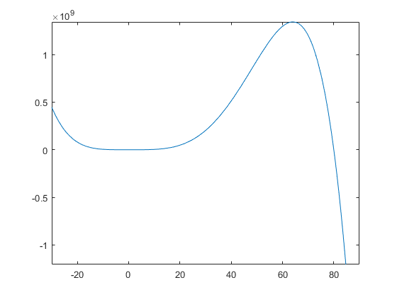

```matlab
poly5 = @(x) - 5*x.^5 + 400*x.^4 + 3*x.^3 + 20*x.^2 - x + 5;
fplot(poly5, [-30,90])
```

- Another example of a MATLAB built-in function function is `fzero`. It tries to find a point `x` where $function(x) = 0$. This function requires a non-linear function, and an initial point.

```matlab
fzero(poly5, 75)
```

```
ans =

   80.0081
```

# Subfunctions

- More complicated functions can be created by grouping functions together in a single file as subfunctions. These subfunctions can be called only from the primary function, so they have limited utility. Subfunctions can be used to modularize your code and to make the primary function easier to read.

```matlab
function [addition result, subtraction result] = subfunction demo(x, y)
% This function both adds and subtracts the elements stored in two arrays
addition result = add(x,y);
subtraction result = subtract(x,y);

function result = add(x,y) % subfunction plus
result = x + y;
end

function output = subtract(x,y) %subfunction minus
output = x - y;
end

end
```

# Output Statements: disp

- `disp`: Displays the result of an expression or a string
- Example 1

```matlab
disp('Hello')
```

```
Hello
```

- Example 2

```matlab
disp(exp(2))
```

```
    7.3891
```

- Example 3

```matlab
x=12;
y=-3;
disp(x+y)
```

```
     9
```

# Output Statements: fprintf

- `fprintf`: Prints formatted output to the screen
- Example 1

```matlab
cows = 5;
fprintf('There are %f cows in the pasture \n', cows)
```

```
There are 5.000000 cows in the pasture
```

- Example 2

```matlab
fprintf('There are %d cows in the pasture \n', cows)
```

```
There are 5 cows in the pasture
```

- Example 3

```matlab
fprintf('The value is %d, for sure! \n', cows)
```

```
The value is 5, for sure!
```

- In the first example below, % character denotes the start of a format specifier requesting a field of width 10 with 3 digits after the decimal point and \n denotes a new line.
- For a negative number, a minus sign occupies one position of the field width.

```matlab
fprintf('%10.3f\n', pi)
```

```
     3.142
```

```matlab
fprintf('%10.4e\n', pi)
```

```
3.1416e+00
```

```matlab
fprintf('%-5.0f\n%5.0f', 9, 103)
```

```
9
  103
```

- MATLAB will repeat the string in the `fprintf` command until it uses all the values in the matrix.

```matlab
x=1:5;
fprintf('%10.2f\n', x);
```

```
      1.00
      2.00
      3.00
      4.00
      5.00
```

- If the variable is a two-dimensional matrix, MATLAB uses the values one column at a time, going down the first column, then the second, and so on. Here’s a more complicated example:

```matlab
feet = 1:3;
inches = feet.*12;
table = [feet;inches]
```

```
table =

     1     2     3
    12    24    36
```

```matlab
fprintf('%7.0f %15.3f \n', table);
```

```
      1          12.000
      2          24.000
      3          36.000
```

# Type Field Format

| Code | Format |
| --- | --- |
| %f | Fixed-point notation |
| %e | Exponential notation |
| %d | Decimal notation - does not include trailing zeros if the value displayed is an integer. If the number includes a fractional component, it is displayed using exponential notation. |
| %g | Whichever is shorter, %f or %e |
| %c | Character information (displays one character at a time) |
| %s | String of characters (displays the entire string) |

# Output Statements: sprintf

- The `sprintf` function is similar to `fprintf`, but instead of just sending the result of the formatted string to the command window, `sprintf` assigns it a name and sends it to the command window.

```matlab
fprintf('Some example output is %10.2f \n', pi*1000)
```

```
Some example output is    3141.59
```

```matlab
sprintf('Some example output is %10.2f \n', pi*1000)
```

```
ans =

    'Some example output is    3141.59
     '
```

# Graphical Input

- MATLAB offers a technique for entering ordered pairs of `x` and `y` values graphically.

  The `ginput` command allows the user to select points from a figure window and converts the points into the appropriate x and y coordinates.
- `[x,y] = ginput(n)`: Requests the user to select `n` points from the figure windows.
- `[x,y] = ginput`: Accepts points until the return key is pressed.

# User-defined Input

- `input('text-string')`: Allows the user to input values of a matrix from the keyboard while the program is running.
- It displays a text string in the command window and then waits for the user to provide the requested input.

  `x = input('Enter a value')`
- If a character or string input is desired, `'s'` must be added after the prompt:

  `y = input('Enter your name', 's')`

# Import/Export Data

- If you select a data file from the current folder and double-click on the file name, the Import Wizard launches.
- The Import Wizard determines what kind of data is in the file and suggests ways to represent the data in MATLAB.
  - `xlsread('filename.xls')`: Imports data from Excel
  - `xlswrite('filename.xls', M)`: Exports data to Excel